## Rationale

The lack of coherent and comparable data on migration restricts our ability to design appropriate migration and development policies, protect and assist migrant populations, and monitor progress towards the achievement of migration-relevant targets in the Sustainable Development Goals (SDGs). This is particularly true for migration movements across the Global South, international migration movements at the subnational-unit level (i.e. between spatial units located in different countries), and migration data disaggregated by basic characteristic such as sex.

This project aims to address this challenge by providing a new globally consistent and harmonized dataset of sex-disaggregated migration movements estimates at the subnational level within and between all low- and middle-income countries. The new dataset is available here. This dashboard provides interactive mapping and visualization of this new dataset.

## Study area

The dataset is available for 121 countries of the Global South shown on Map 1.[^1]

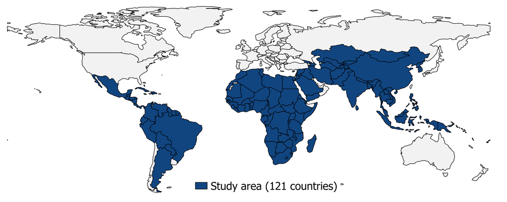

Map 1: Study area

## Definitions

### *Migration*

An *international* migrant is defined here as a person who has **changed country of residence within 5 years**. For instance, a person having migrated from country *A* to country *B* and having resided less than 2 years in country *B* is counted as an international migrant, but a person having migrated 10 years ago in country *B* is not considered as a migrant anymore.

Similarly, an *internal* migrant is defined here as a person who has **changed administrative unit of residence within 5 years prior to census**.

These figures provide hence medium term migration movements.

### *Administrative unit*

An administrative unit is a country subdivision: a “country may be divided into provinces, states, counties, cantons or other sub-units, which, in turn, may be divided in whole or in part into municipalities, counties or others” ([Wikipedia](https://en.wikipedia.org/wiki/Administrative_division)).

Level 1 and 2 administrative units are used for most countries. These level 1 administrative units are called *regions* in Tanzania and *provinces* in the Democratic Republic of Congo, for instance.

### *Estimates*

These migration figures are derived from statistical models and are meant to be *estimates*. See tab the tab **Internal migration estimates** for as summary of the goodness of fit of the models.

These *estimates* are based on the 2000 and 2010 rounds of census (see Map 2 and 3). Hence, the estimates won’t capture migration out of Syria in the follow-up of the current Syrian crisis for instance.

When referring to the migration estimates, one needs to assume that the main drivers and directions of migration have not changed since 2010.

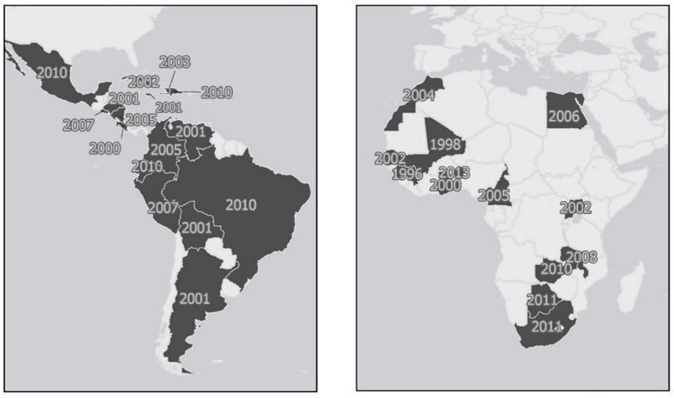

Map 2: Years of censuses used in this study in Latin America, Caribbean and Africa

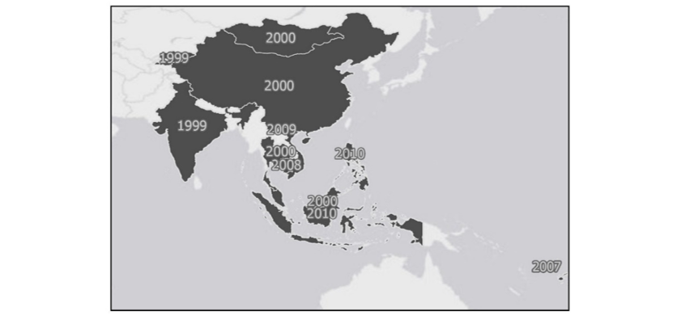

Map 3: Years of censuses used in this study in Asia

## Data sources and methods

The estimates are built upon three core bodies of data:

1. IPUMSI database: It contains data on migration for 40 low- and middle-income countries ([IMPUMSI database](https://international.ipums.org/international/), see the Tab on **Internal migration estimates** for details)
2. Geospatial covariates: A suite of covariates, representing pull and push factors known to influence internal migration, derived from globally available GIS- and Remote Sensing-based datasets (see the tab **Geographic Information System (GIS) Covariates** for details)
3. Gender Disaggregated Country Level International Migration Flows estimates (hereafter, ADRI database): Country level gender-disaggregated international migration estimates produced by Professor Guy Abel, ADRI, Shanghai University, China (Abel, [2018](https://onlinelibrary.wiley.com/doi/abs/10.1111/imre.12327), Azose & Raftery, [2019](https://www.pnas.org/content/116/1/116), see the Tab **International migration estimates** for details).

The approach can be summarised in three main steps: